This tutorial is automatically generated from the file test/python/cell_based/tutorials/TestScratchAssayTutorial.py.

```python
# Jupyter notebook specific imports
import matplotlib as mpl
import matplotlib.pyplot as plt
from IPython import display
%matplotlib inline
```

# Introduction

This tutorial is an example of modelling a scratch assay using a simple cellular automaton representation of cells. It will cover the following techniques:

- Setting up a regular mesh (or lattice)
- Visualizing the mesh
- Working with file-based output
- Generating cells and adding them to the mesh
- Simulating cell migration on the mesh
- Real-time visualization of the cell population and plotting of population statistics

```python
import numpy as np # Matrix tools
import chaste # The PyChaste module
chaste.init() # Set up MPI
import chaste.cell_based # Contains cell populations
import chaste.mesh # Contains meshes
import chaste.visualization # Visualization tools
```

## Test 1 - Scratch Assay

In this test we will create a scratch along the middle of a domain and quantify the migration of cells into the region. Cells will migrate by random walk on the their regular mesh (lattice).

Chaste is based on the concept of `Cells` and `Meshes`. 'Cells' do not store their position in space, or connectivity, these are managed by a `Mesh`. The first step in most Chaste simulations is to set up a mesh, on which we can locate cells. A collection of `Cells` and a `Mesh` are a `Cell Population` in Chaste terminology. The most simple `Cell Population` is the `CaBasedCellPopulation` which corresponds to cells occupying discrete locations on a regular mesh (lattice). Our first step is to set up the mesh. Here we set up a 2D lattice.

```python
# Set up the test
chaste.cell_based.SetupNotebookTest()

num_points_in_x = 100
num_points_in_y = 12
generator = chaste.mesh.PottsMeshGenerator2(num_points_in_x, 0, 0, num_points_in_y, 0, 0)
mesh = generator.GetMesh()
```

Note that we are using a `PottsMeshGenerator2` to set up the grid and we are setting some terms to 0. Chaste design is based on re-use of components, the `PottsMeshGenerator` can be used to set up other types of cell population which require these extra terms. Note also the '2' at the end of the class name. This tells us that we are working in 2D. Most Chaste classes are specialized (templated) for spatial dimension, so we need to make sure we are consistent in the dimensionality of the classes we are using.

Next we set up some cells. We create and empty container `VecCellPtr` (which will behave like a Python list) and will fill it with cells of our chosen type. In Chaste cells can be assinged a number of proliferative types (Default, Differentiated, Stem, Transit or User Defined). These types will define how cells behave in certain simulations, for example whether they will proliferate. We just want our cells to migrate in this example, so we set a DifferentiatedCellProliferativeType.

```python
cells = chaste.cell_based.VecCellPtr()
differentiated_type = chaste.cell_based.DifferentiatedCellProliferativeType()
```

We are not interested in cell cycling so we specialize the generator to NoCellCycleModel.

```python
cell_generator = chaste.cell_based.CellsGeneratorNoCellCycleModel_2()
```

We want two sets of cells, starting on opposite sides of the mesh. We use `location_indices` to map cells onto locations (or Nodes) on the mesh. For our regular mesh the Node indices increase fastest in x, then y. We will add four layers of cells to each side of the mesh.

```python
num_cell_layers = 4
bottom_location_indices = range(num_cell_layers*num_points_in_x)
num_grid_points = num_points_in_x*num_points_in_y
top_location_indices = range(num_grid_points-1, num_grid_points - num_cell_layers*num_points_in_x-1, -1)
cell_generator.GenerateGivenLocationIndices(cells, bottom_location_indices + top_location_indices,
                                            differentiated_type)
```

Now we have a mesh and a set of cells to go with it, we can create a CellPopulation.

```python
cell_population = chaste.cell_based.CaBasedCellPopulation2(mesh, cells, bottom_location_indices +
                                                           top_location_indices)
```

```python
simulator = chaste.cell_based.OnLatticeSimulation2(cell_population)
simulator.SetOutputDirectory("Python/TestScratchAssayTutorial")
simulator.SetEndTime(10.0)
simulator.SetDt(0.1)
simulator.SetSamplingTimestepMultiple(1)
```

We must now create a rule for cell migration. We will use an existing diffusion type rule.

```python
diffusion_update_rule = chaste.cell_based.DiffusionCaUpdateRule2()
simulator.AddUpdateRule(diffusion_update_rule)
```

PyChaste can do simple 3D rendering with VTK. We set up a `VtkScene` so that we can see the population evovle in real time.

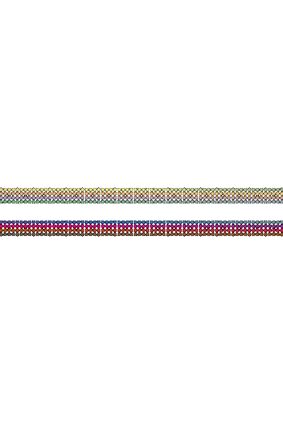

```python
scene= chaste.visualization.VtkScene2()
scene.SetCellPopulation(cell_population)
scene.GetCellPopulationActorGenerator().SetShowCellCentres(True)
nb_manager = chaste.visualization.JupyterNotebookManager()
nb_manager.vtk_show(scene, height=600)
```

We add the scene to the simulation for real-time updating using a `VtkSceneModifier`. Such modifiers are called by the simulator at regular periods during the main time loop and have access to the cell population. We will use a similar idea in a moment to record cell positions for real time plotting.

```python
scene_modifier = chaste.visualization.JupyterSceneModifier2(nb_manager)
scene_modifier.SetVtkScene(scene)
scene_modifier.SetUpdateFrequency(10)
simulator.AddSimulationModifier(scene_modifier)
```

Chaste and PyChaste use object oriented programming. This may require some background reading, but allows for great flexibility in terms of modifying existing functionality. In order to pull the data we want out of the simulation as it runs we will create our own simulation modifier class and use it for real time plotting. This Python class over-rides one of the built-in classes, giving us access to the quantities we want during the simulation. Usually we would define such a class in a different module and import it, it is placed here for the purposes of the tutorial.

```python
class PlottingModifier(chaste.cell_based.AbstractCellBasedSimulationModifier2_2):

    """ Class for real time plotting of cell numbers using Matplotlib
    """

    def __init__(self, num_points_in_x, num_points_in_y):
        super(PlottingModifier, self).__init__()

        # Set up a figure for plotting
        plt.ioff()
        self.fig = plt.figure()
        self.fig.ax = self.fig.add_subplot(111)
        self.fig.ax.set_xlabel("y - Position (Cell Lengths)")
        self.fig.ax.set_ylabel("Number Of Cells")
        self.plot_frequency = 10 # only plot every 10 steps
        self.num_points_in_x = num_points_in_x
        self.num_points_in_y = num_points_in_y

    def UpdateAtEndOfTimeStep(self, cell_population):

        """ Plot the number of cells at each lattice point and time-point

        Use the SimulationTime singleton to determine when to plot.
        """

        num_increments = chaste.cell_based.SimulationTime.Instance().GetTimeStepsElapsed()
        if num_increments % self.plot_frequency == 0:
            y_locations = np.linspace(0, num_points_in_y, num_points_in_y)
            num_cells = []
            for idx in range(num_points_in_y):
                counter = 0
                for jdx in range(num_points_in_x):
                    if cell_population.IsCellAttachedToLocationIndex(jdx + idx*num_points_in_x):
                        counter +=1
                num_cells.append(counter)

            self.fig.ax.plot(y_locations, num_cells, color='black')
            self.fig.canvas.draw()
            display.display(self.fig)
            display.clear_output(wait=True)

    def SetupSolve(self, cell_population, output_directory):

        """ Make sure the cell population is in the correct state at the start of the simulation
        """

        cell_population.Update()

    def OutputSimulationModifierParameters(self, rParamsFile):

        """ This needs to be explicitly over-ridden as the C++ method is pure virtual.
        """

        pass

plotting_modifier = PlottingModifier(num_points_in_x, num_points_in_y)
simulator.AddSimulationModifier(plotting_modifier)
```

To run the simulation, we call `Solve()` and optionally set up interactive plotting. We will see the cells migrate and the population distribution gradually become more uniform.

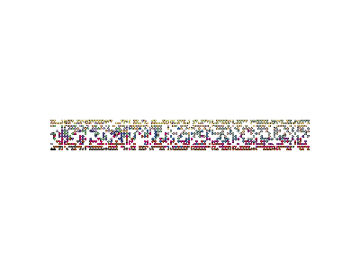

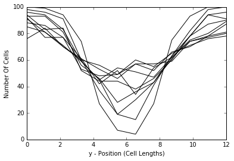

```python
scene.Start()
plt.ion()
plt.show()
simulator.Solve()
```